# Eartquake Histograms

Leonardo Alvarado

10/07/2015

This application was designed to plot two type of histograms from real database of earthquakes that occured between 2000 and 2010 in Venezuela.

## The Shiny Aplication

The histograms that can be plotted are:

1. Number of seismic events per year
2. Number of seismic events per magnitud,

since 2000 up to selected year (max 2010); you can see the number of eartquake occurred in the region of Venezuela, between latitude 5 to 14ºN and longitude 58 to 74ºW (or -74 to -58), the region of interest can be modified. The database was provided by FUNVISIS (Fundación Venezolana de Investigaciones Sismológicas).

## Controls of the app.

The app contain the following controls:

- **Slider Control:** To modify the period of time to plot, from 2000 to whatever year between 2000 and 2010. (The initial year can’t be changed).
- **Numeric Input control:** There are 4 controls (latitude min, latitude max, longitude min and longitude max) you can select seismic events in the desired region. The desired region should be between latitude 5 to 14 (ºN) and longitude -74 to -54 (ºW)
- **Select Input control:** You can choose between two options: **Year** to see the number of events per year or **Magnitude** to see the number events per Magnitud.
- A **map** of the initial region is located in the main panel as a reference, it can’t be modified.

## Results of the app

1. The histogram plotted when you select Histogram **Year** is the following:

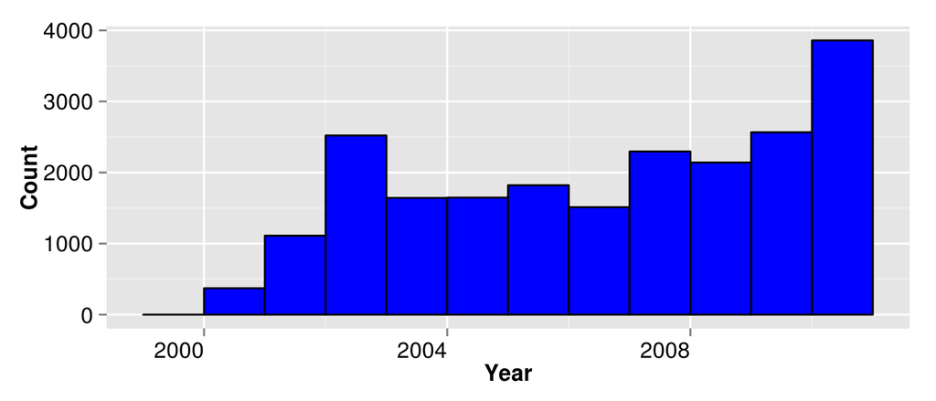

This the histograms of the seismic events per year ocurred in Venezuela between 2000 and 2010.

2. The histogram showed when you select Histogram **Magnitude** is the folowing:

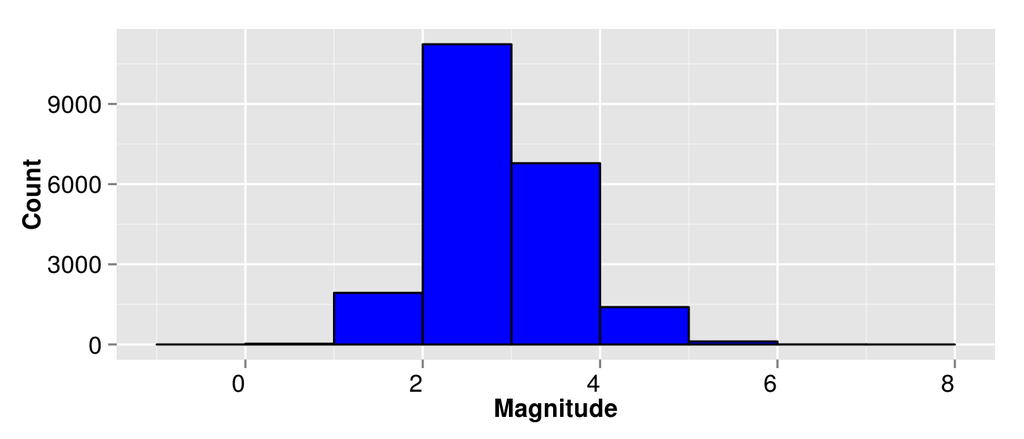

This the histograms of the seismic events per magnitude ocurred in Venezuela between 2000 and 2010